# Medical Devices Package

Sahar Abuzaid

## Aim of project

This project aim to create a medical devices data package that public, readable, downloadable.

## Dataset

The raw dataset that used in this project provided from [ICIJ](https://medicaldevices.icij.org/p/download) The raw data contain 3 files: devices, events, manufacturers.

## Cleaning data

### Challenges

- The data is huge and messy data.
- There is a large number of missing value, because the data collected from different health authorities in different countries.
- There is no formal matrices in the columns.
- Duplication in data rows.

### Assumptions

- Remove the columns that have more than 75% missing values; To keep some important columns.
- To reduce the size of the data and formalize the matrices across the rows; Filter the data to have only the data provided by U.S.FDA.

##### Load the packges and the dataset

```r
#Import packages:
library(tidyverse)
library(visdat)
library(stringr)
#Read the data
devices <- read_csv('data-raw/devices-1574540427.csv')
events <- read_csv('data-raw/events-1574540448.csv')
manufacturers <- read_csv('data-raw/manufacturers-1574540422.csv')
```

##### Visiualize the missing value

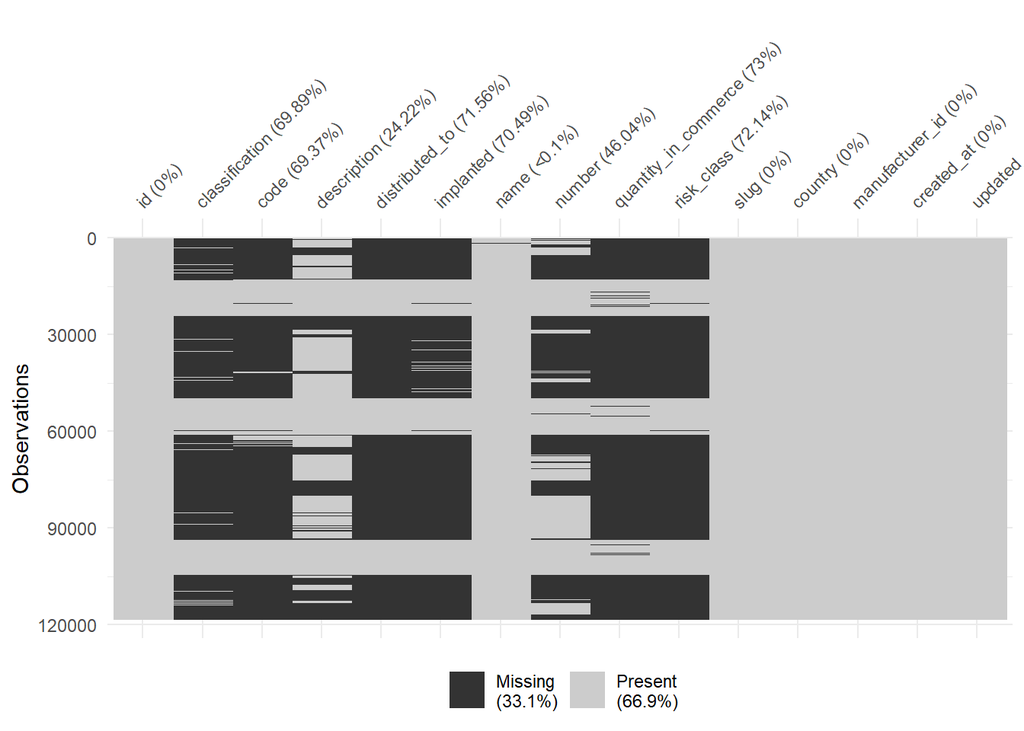

```r
# Visualize the missing value in devices:

vis_miss(devices, warn_large_data = FALSE)
```

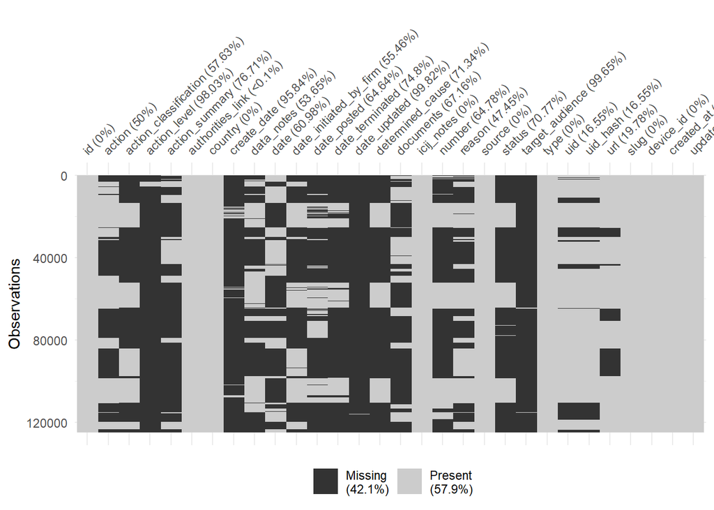

```r
# Visualize the missing value in devices:

vis_miss(events, warn_large_data = FALSE)
```

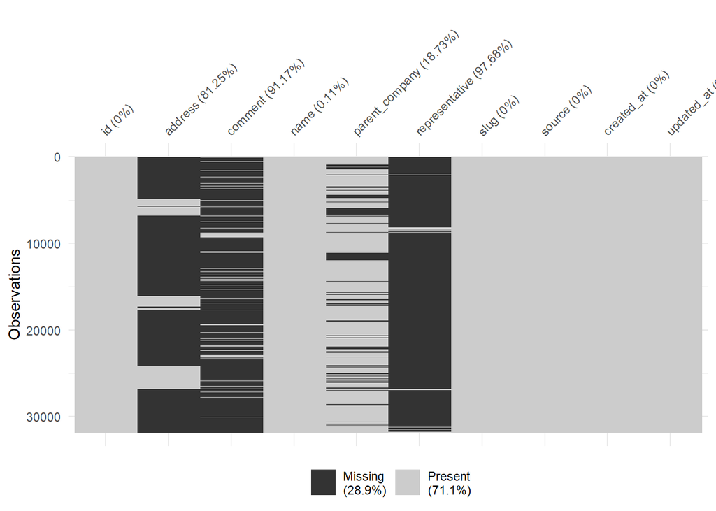

```r
# Visualize the missing value in devices:

vis_miss(manufacturers, warn_large_data = FALSE)
```

##### Change the name of the columns that have the same name in 2 or more file(e.g. id, slug):

```r
names(devices)[1] <- "device_id"
names(devices)[2] <- "device_classification"
names(devices)[7] <- "device_name"
names(events)[1] <- "event_id"
names(events)[3] <- "Recall_classification"
names(manufacturers) [1] <- "manufacturer_id"
names(manufacturers) [7] <- "manufacturers_slug"
names(manufacturers) [4] <- "manufacturers_name"
```

##### Delete the columns that have the same information(Except the column that will use to marge the data frames)

```r
events <- select(events, -c(slug, created_at, updated_at, country))
manufacturers <- select(manufacturers, -c(created_at, updated_at, source))
```

##### Delete the columns that have parentage of missing value > 75% :

```r
events <- select(events, -c(action_level, action_summary, create_date, date_updated, target_audience))
manufacturers <- select(manufacturers, -c(address, comment, representative))
```

##### Remove the Irrelevant/uninformative columns:

```r
devices <- select(devices, -c(number, slug, created_at, updated_at,code, description))
events <- select(events, -c(icij_notes, number, uid, uid_hash, url, documents, authorities_link, date ))
manufacturers <- select(manufacturers, -c(manufacturers_slug))
```

##### Merge the manufacturers data with devices data using the manufacturer_id

```r
Marge_data <- merge(devices, manufacturers, by = 'manufacturer_id')
```

##### Merging the devices data with events can be done by using ID and device_id

```r
df <- merge(Marge_data, events, by = 'device_id')
```

##### Remove rows that contain Missing value:

```r
df <- na.omit(df)
```

##### Remove the duplicate/ unique value along the columns:

```r
df <- df %>%
  distinct(device_id, .keep_all = TRUE)
```

##### The only country we have is USA, so there is no need for the country, source column

Also, all the rows in the same type “Recall”, and same status, so there is no need for these columns

```r
unique(df$country, incomparables = FALSE)
```

```
## [1] "USA"
```

```r
unique(df$type, incomparables = FALSE)
```

```
## [1] "Recall"
```

```r
unique(df$status, incomparables = FALSE)
```

```
## [1] "Terminated"
```

```r
df <- select(df, -c(country, type, status, source))
```

##### After linking the 3 data sets, the manufacturer_id and the event_id can removed:

```r
df <- select(df, -c(manufacturer_id, event_id))
```

##### Remove the duplicate AGAIN

```r
df <- df %>%
  distinct(device_classification, device_name, action, reason,data_notes, .keep_all = TRUE)
```

##### The information in the (distribute to) column are messy and can’t be used for further analysis

fix the formality to be either(worldwide, nationwide, or undefined)

```r
MedDevices <- df %>%
  mutate(distributed_to = case_when(
    str_detect(distributed_to, "Worldwide") ~ "worldwide",
    str_detect(distributed_to, "France") ~ "worldwide",
    str_detect(distributed_to, "Canada") ~ "worldwide",
    str_detect(distributed_to,"CANADA") ~ "worldwide",
    str_detect(distributed_to, "No foreign") ~ "nationwide",
    str_detect(distributed_to, "no foreign") ~ "nationwide",
    str_detect(distributed_to, "Foreign") ~ "worldwide",
    str_detect(distributed_to, "countries") ~ "worldwide",
    str_detect(distributed_to, "Internationally") ~ "worldwide",
    str_detect(distributed_to, "International") ~ "worldwide",
    str_detect(distributed_to, "Columbia") ~ "worldwide",
    str_detect(distributed_to, "Italy") ~ "worldwide",
    str_detect(distributed_to, "Belgium") ~ "worldwide",
    str_detect(distributed_to, "Australia") ~ "worldwide",
    str_detect(distributed_to, "Japan") ~ "worldwide",
    str_detect(distributed_to, "AUSTRIA") ~ "worldwide",
    str_detect(distributed_to, "Africa") ~ "worldwide",
    str_detect(distributed_to, "OUS") ~ "worldwide",
    str_detect(distributed_to, "Mexico") ~ "worldwide",
    str_detect(distributed_to, "worldwide") ~ "worldwide",
    str_detect(distributed_to, "Europe") ~ "worldwide",
    str_detect(distributed_to, "Saudi Arabia") ~ "worldwide",
    str_detect(distributed_to, "Germany") ~ "worldwide",
    str_detect(distributed_to, "Netherlands") ~ "worldwide",
    str_detect(distributed_to, "China") ~ "worldwide",
    str_detect(distributed_to, "Ireland") ~ "worldwide",
    str_detect(distributed_to, "Finland") ~ "worldwide",
    str_detect(distributed_to, "internationally") ~ "worldwide",
    str_detect(distributed_to, "no international") ~ "nationwide",
    str_detect(distributed_to, "international") ~ "worldwide",
    str_detect(distributed_to, "other foreign") ~ "worldwide",
    str_detect(distributed_to, "and foreign") ~ "worldwide",
    str_detect(distributed_to, "United Kingdom") ~ "worldwide",
    str_detect(distributed_to, "JAPAN") ~ "worldwide",
    str_detect(distributed_to, "Spain") ~ "worldwide",
    str_detect(distributed_to, "Wordwide") ~ "worldwide",
    str_detect(distributed_to, "ISRAEL") ~ "worldwide",
    str_detect(distributed_to, "UK") ~ "worldwide",
    str_detect(distributed_to, "Switzerland") ~ "worldwide",
    str_detect(distributed_to, "Nationwide and international") ~ "worldwide",
    str_detect(distributed_to, "Srialanka") ~ "worldwide",
    str_detect(distributed_to, "Sweden") ~ "worldwide",
    str_detect(distributed_to, "Kuwait") ~ "worldwide",
    str_detect(distributed_to, "Middle East") ~ "worldwide",
    str_detect(distributed_to, "Canadian") ~ "worldwide",
    str_detect(distributed_to, "KOREA") ~ "worldwide",
    str_detect(distributed_to, "Korea") ~ "worldwide",
    str_detect(distributed_to, "Brazil") ~ "worldwide",
    str_detect(distributed_to, "states") ~ "nationwide",
    str_detect(distributed_to, "state") ~ "nationwide",
    str_detect(distributed_to, "State") ~ "nationwide",
    str_detect(distributed_to, "States") ~ "nationwide",
    str_detect(distributed_to, "USA only") ~ "nationwide",
    str_detect(distributed_to, "To PR only") ~ "nationwide",
    str_detect(distributed_to, "nation wide") ~ "nationwide",
    str_detect(distributed_to, "nationwide") ~ "nationwide",
    str_detect(distributed_to, "Bentonville") ~ "nationwide",
    str_detect(distributed_to, "Nationally") ~ "nationwide",
    str_detect(distributed_to, "US distribution only") ~ "nationwide",
    str_detect(distributed_to, "Domestic") ~ "nationwide",
    str_detect(distributed_to, "US Distribution") ~ "nationwide",
    str_detect(distributed_to, "domestic") ~ "nationwide",
    str_detect(distributed_to, "Nationwide") ~ "nationwide",
    str_detect(distributed_to, "world") ~ "worldwide",
    str_detect(distributed_to, "Argentina") ~ "worldwide",
    str_detect(distributed_to, "US distribution") ~ "nationwide",
    str_detect(distributed_to, "AZ") ~ "nationwide",
    str_detect(distributed_to, "TX") ~ "nationwide",
    str_detect(distributed_to, "Distributed to") ~ "nationwide",
    str_detect(distributed_to, "throughout the") ~ "nationwide",
    str_detect(distributed_to, "PA") ~ "nationwide",
    str_detect(distributed_to, "CA") ~ "nationwide",
    str_detect(distributed_to, "FL") ~ "nationwide",
    str_detect(distributed_to, "Distributed in") ~ "nationwide",
    str_detect(distributed_to, "NY") ~ "nationwide",
    str_detect(distributed_to, "US") ~ "nationwide",
    str_detect(distributed_to, "Texas") ~ "nationwide",
    str_detect(distributed_to, "OH") ~ "nationwide",
    str_detect(distributed_to, "U.S.") ~ "nationwide",
    str_detect(distributed_to, "Single US") ~ "nationwide",
    str_detect(distributed_to, "single") ~ "nationwide",
    str_detect(distributed_to, "NC") ~ "nationwide",
    str_detect(distributed_to, "Indiana") ~ "nationwide",
    str_detect(distributed_to, "UT") ~ "nationwide",
    str_detect(distributed_to, "MA") ~ "nationwide",
    str_detect(distributed_to, "Maryland") ~ "nationwide",
    str_detect(distributed_to, "Florida") ~ "nationwide",
    str_detect(distributed_to, "California") ~ "nationwide",
    str_detect(distributed_to, "only") ~ "nationwide",
    str_detect(distributed_to, "Natonwide Distribution") ~ "nationwide",
    str_detect(distributed_to, "USA") ~ "nationwide",
    str_detect(distributed_to, "MO") ~ "nationwide",
    str_detect(distributed_to, "MN") ~ "nationwide",
    str_detect(distributed_to, "Puerto Rico") ~ "nationwide",
    str_detect(distributed_to, "Illinois") ~ "nationwide",
    str_detect(distributed_to, "IL") ~ "nationwide",
    str_detect(distributed_to, "MI") ~ "nationwide",
    str_detect(distributed_to, "one") ~ "nationwide",
    str_detect(distributed_to, "NJ") ~ "nationwide",
    str_detect(distributed_to, "CO") ~ "nationwide",
    str_detect(distributed_to, "DE") ~ "nationwide",
    str_detect(distributed_to, "LA") ~ "nationwide",
    str_detect(distributed_to, "MN") ~ "nationwide",
    str_detect(distributed_to, "Massachusetts") ~ "nationwide",
    str_detect(distributed_to, "VA") ~ "nationwide",
    str_detect(distributed_to, "Utah") ~ "nationwide",
    str_detect(distributed_to, "Pennsylvania") ~ "nationwide",
    str_detect(distributed_to, "Virginia") ~ "nationwide",
    str_detect(distributed_to, "Wisconsin") ~ "nationwide",
    str_detect(distributed_to, "OR") ~ "nationwide",
    str_detect(distributed_to, "GA") ~ "nationwide",
    str_detect(distributed_to, "NE") ~ "nationwide",
    str_detect(distributed_to, "The") ~ "undefind",
    str_detect(distributed_to, "later") ~ "undefind",
    str_detect(distributed_to, "Apple") ~ "undefind",
    str_detect(distributed_to, "list") ~ "undefind",
    str_detect(distributed_to, "population") ~ "undefind",

    TRUE ~ distributed_to
  ))
```

##### Remove (Device Recall) from all names of devices:

```r
MedDevices <- MedDevices %>%
  mutate(device_name = str_remove_all(device_name, "Device Recall"))
```

##### Remove some rows that contain messy name:

```r
MedDevices <- MedDevices[-c(6282, 11039, 7168), ]
```

##### Remove the column that has very messy and not uniform data:

```r
MedDevices <- select(MedDevices, -c(quantity_in_commerce, data_notes, action))
```

##### Reorder the columns and rows in data frame:

```r
col_order <- c("device_id", "device_name", "device_classification","manufacturers_name", "parent_company","distributed_to",
               "implanted", "risk_class", "reason", "determined_cause", "Recall_classification", "date_initiated_by_firm",
               "date_posted", "date_terminated")
MedDevices <- MedDevices[, col_order]

MedDevices$device_id <- 1:nrow(MedDevices)
```

## Results

The final data frame has 12423 rows and 14 variables The data frame contains the following variables:

##### `device_id` : Distinction number for each device in the data.

##### `device_name`: Name of the device.

##### `device_classification`: The class of the device base on hospital department that the device used in.It include 16 classes.

| Index | Class |
| --- | --- |
| 1 | General Hospital and Personal Use Devices |
| 2 | Clinical Chemistry and Clinical Toxicology Devices |
| 3 | Radiology Devices |
| 4 | Neurological Devices |
| 5 | General and Plastic Surgery Devices |
| 6 | Orthopedic Devices |
| 7 | Cardiovascular Devices |
| 8 | Immunology and Microbiology Devices |
| 9 | Hematology and Pathology Devices |
| 10 | Anesthesiology Devices |
| 11 | Gastroenterology-Urology Devices |
| 12 | Physical Medicine Devices |
| 13 | Ophthalmic Devices |
| 14 | Obstetrical and Gynecological Devices |
| 15 | Dental Devices |
| 16 | Ear, Nose, and Throat Devices |

##### `manufacturers_name` Name of device’s manufacturer.

##### `parent_company` Name of manufacturer’s parent company.

##### `distributed_to` The spatial distribution of the device.Either: `worldwide`, `nationwide`, or `undefind`

##### `implanted` The device implantable or not.

##### `risk_class` The class of the device base on risk level.

| Risk Class | Description |
| --- | --- |
| 1 | Low-risk devices |
| 2 | Intermediate-risk devices |
| 3 | High-risk devices that are very important to health or sustaining life. |
| HDE | Humanitarian Use Device |
| Unclassified / Not classified | The device does not classify to any class |

##### `reason` The potential danger due to recalled malfunction.

##### `determined_cause` The cause of the malfunction.

##### `Recall_classification` The relative degree of risk.

| Recall class | Description |
| --- | --- |
| Class 1 | A situation where there is a reasonable chance that a product will cause serious health problems or death |
| Class 2 | A situation where a product may cause a temporary or reversible health problem or where there is a slight chance that it will cause serious health problems or death. |
| Class 3 | A situation where a product is not likely to cause any health problem or injury. |

##### `date_initiated_by_firm` Initiation date of recall by the company.

##### `date_posted` Date of posting the recall by FDA in database.

##### `date_terminated` Date of terminating the recall.

## Instaltion

You can install the development version of MedDevices from [GitHub](https://github.com/sahar979/MedDevices) with:

```r
# install.packages("devtools")
devtools::install_github("sahar979/MedDevices")
```